# Codebook - The Dark Triad and attractiveness in speed dating

- Metadata
- Variables
  - SD_Code
  - DG
  - DG_size
  - DG_size_acq
  - age
  - sex
  - height
  - weight
  - relStat
  - relStat_other
  - education
  - contracept
  - date
  - NPI_avg
  - SRP_avg
  - MACHIV_avg
  - BFI_N_avg
  - BFI_E_avg
  - BFI_O_avg
  - BFI_A_avg
  - BFI_C_avg
  - PA_R1
  - PA_R2
  - PA_R3
  - PA_R4
  - PA_avg
  - BMI
  - SOI_R_B_avg
  - SOI_R_A_avg
  - SOI_R_D_avg
  - TargEff__choice_relFrequ_acq {#TargEff__choice_relFrequ_acq .tabset}
  - TargEff__FS_avg_acq {#TargEff__FS_avg_acq .tabset}
  - TargEff__ONS_avg_acq {#TargEff__ONS_avg_acq .tabset}
  - TargEff__BC_avg_acq {#TargEff__BC_avg_acq .tabset}
  - TargEff__FWB_avg_acq {#TargEff__FWB_avg_acq .tabset}
  - TargEff__STR_avg_acq {#TargEff__STR_avg_acq .tabset}
  - TargEff__LTR_avg_acq {#TargEff__LTR_avg_acq .tabset}
  - TargEff__PA_avg_acq {#TargEff__PA_avg_acq .tabset}
  - TargEff__Like_avg_acq {#TargEff__Like_avg_acq .tabset}
  - TargEff__Int_avg_acq {#TargEff__Int_avg_acq .tabset}
  - TargEff__FIPI_N_avg_acq {#TargEff__FIPI_N_avg_acq .tabset}
  - TargEff__FIPI_E_avg_acq {#TargEff__FIPI_E_avg_acq .tabset}
  - TargEff__FIPI_O_avg_acq {#TargEff__FIPI_O_avg_acq .tabset}
  - TargEff__FIPI_A_avg_acq {#TargEff__FIPI_A_avg_acq .tabset}
  - TargEff__FIPI_C_avg_acq {#TargEff__FIPI_C_avg_acq .tabset}
  - PercEff__choice_relFrequ_acq {#PercEff__choice_relFrequ_acq .tabset}
  - PercEff__FS_avg_acq {#PercEff__FS_avg_acq .tabset}
  - PercEff__ONS_avg_acq {#PercEff__ONS_avg_acq .tabset}
  - PercEff__BC_avg_acq {#PercEff__BC_avg_acq .tabset}
  - PercEff__FWB_avg_acq {#PercEff__FWB_avg_acq .tabset}
  - PercEff__STR_avg_acq {#PercEff__STR_avg_acq .tabset}
  - PercEff__LTR_avg_acq {#PercEff__LTR_avg_acq .tabset}
  - PercEff__PA_avg_acq {#PercEff__PA_avg_acq .tabset}
  - PercEff__Like_avg_acq {#PercEff__Like_avg_acq .tabset}
  - PercEff__Int_avg_acq {#PercEff__Int_avg_acq .tabset}
  - PercEff__FIPI_N_avg_acq {#PercEff__FIPI_N_avg_acq .tabset}
  - PercEff__FIPI_E_avg_acq {#PercEff__FIPI_E_avg_acq .tabset}
  - PercEff__FIPI_O_avg_acq {#PercEff__FIPI_O_avg_acq .tabset}
  - PercEff__FIPI_A_avg_acq {#PercEff__FIPI_A_avg_acq .tabset}
  - PercEff__FIPI_C_avg_acq {#PercEff__FIPI_C_avg_acq .tabset}
- Missingness report
- Codebook table

Here, we’re just setting a few options.

```r
knitr::opts_chunk$set(
  warning = TRUE, # show warnings during codebook generation
  message = TRUE, # show messages during codebook generation
  error = TRUE, # do not interrupt codebook generation in case of errors,
                # usually better for debugging
  echo = TRUE  # show R code
)
ggplot2::theme_set(ggplot2::theme_bw())
```

Now, we’re preparing our data for the codebook.

```r
library(codebook)
codebook_data <- codebook::bfi
# to import an SPSS file from the same folder uncomment and edit the line below
# codebook_data <- rio::import("mydata.sav")
# for Stata
# codebook_data <- rio::import("mydata.dta")
# for CSV
# codebook_data <- rio::import("mydata.csv")

# omit the following lines, if your missing values are already properly labelled
codebook_data <- detect_missing(codebook_data,
    only_labelled = TRUE, # only labelled values are autodetected as
                                   # missing
    negative_values_are_missing = FALSE, # negative values are missing values
    ninety_nine_problems = TRUE,   # 99/999 are missing values, if they
                                   # are more than 5 MAD from the median
    )

# If you are not using formr, the codebook package needs to guess which items
# form a scale. The following line finds item aggregates with names like this:
# scale = scale_1 + scale_2R + scale_3R
# identifying these aggregates allows the codebook function to
# automatically compute reliabilities.
# However, it will not reverse items automatically.
codebook_data <- detect_scales(codebook_data)
```

```
## 4 BFIK_open items connected to scale

## 4 BFIK_agree items connected to scale

## 4 BFIK_extra items connected to scale

## 3 BFIK_neuro items connected to scale

## 4 BFIK_consc items connected to scale
```

Create codebook

```r
# source: https://osf.io/jvk3u/
df <- rio::import("DarkTriadDate_person.sav")

# create codebook
codebook::codebook(df)
```

### Metadata

#### Description

**Dataset name**: df

The dataset has N=90 rows and 60 columns. 45 rows have no missing values on any column.

**Metadata for search engines**

- **Date published**: 2021-03-03

| x |
| --- |
| SD_Code |
| DG |
| DG_size |
| DG_size_acq |
| age |
| sex |
| height |
| weight |
| relStat |
| relStat_other |
| education |
| contracept |
| date |
| NPI_avg |
| SRP_avg |
| MACHIV_avg |
| BFI_N_avg |
| BFI_E_avg |
| BFI_O_avg |
| BFI_A_avg |
| BFI_C_avg |
| PA_R1 |
| PA_R2 |
| PA_R3 |
| PA_R4 |
| PA_avg |
| BMI |
| SOI_R_B_avg |
| SOI_R_A_avg |
| SOI_R_D_avg |
| TargEff__choice_relFrequ_acq |
| TargEff__FS_avg_acq |
| TargEff__ONS_avg_acq |
| TargEff__BC_avg_acq |
| TargEff__FWB_avg_acq |
| TargEff__STR_avg_acq |
| TargEff__LTR_avg_acq |
| TargEff__PA_avg_acq |
| TargEff__Like_avg_acq |
| TargEff__Int_avg_acq |
| TargEff__FIPI_N_avg_acq |
| TargEff__FIPI_E_avg_acq |
| TargEff__FIPI_O_avg_acq |
| TargEff__FIPI_A_avg_acq |
| TargEff__FIPI_C_avg_acq |
| PercEff__choice_relFrequ_acq |
| PercEff__FS_avg_acq |
| PercEff__ONS_avg_acq |
| PercEff__BC_avg_acq |
| PercEff__FWB_avg_acq |
| PercEff__STR_avg_acq |
| PercEff__LTR_avg_acq |
| PercEff__PA_avg_acq |
| PercEff__Like_avg_acq |
| PercEff__Int_avg_acq |
| PercEff__FIPI_N_avg_acq |
| PercEff__FIPI_E_avg_acq |
| PercEff__FIPI_O_avg_acq |
| PercEff__FIPI_A_avg_acq |
| PercEff__FIPI_C_avg_acq |

## Variables

### SD_Code

speed dating code

#### Distribution

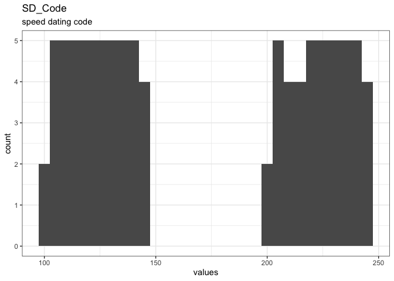

0 missing values.

#### Summary statistics

| name | label | data_type | n_missing | complete_rate | min | median | max | mean | sd | hist | format.spss |
| --- | --- | --- | --- | --- | --- | --- | --- | --- | --- | --- | --- |
| SD_Code | speed dating code | numeric | 0 | 1 | 101 | 146 | 246 | 172.6333 | 52.2639 | ▇▅▁▃▇ | F8.0 |

### DG

dating group

#### Distribution

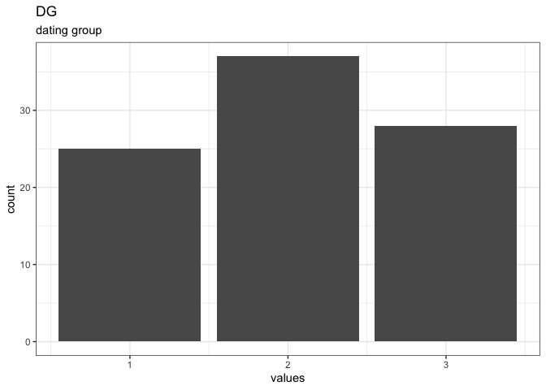

0 missing values.

#### Summary statistics

| name | label | data_type | n_missing | complete_rate | min | median | max | mean | sd | hist | format.spss |
| --- | --- | --- | --- | --- | --- | --- | --- | --- | --- | --- | --- |
| DG | dating group | numeric | 0 | 1 | 1 | 2 | 3 | 2.033333 | 0.7709618 | ▆▁▇▁▆ | F8.0 |

### DG_size

dating group size

#### Distribution

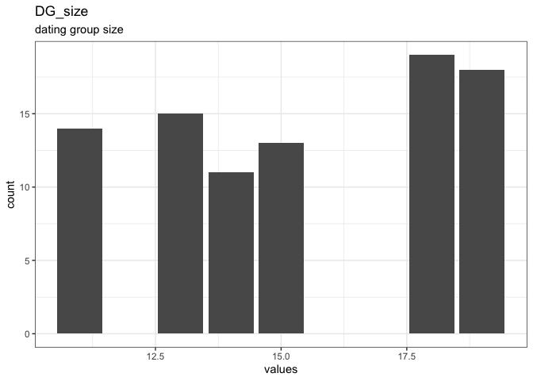

0 missing values.

#### Summary statistics

| name | label | data_type | n_missing | complete_rate | min | median | max | mean | sd | hist | format.spss |
| --- | --- | --- | --- | --- | --- | --- | --- | --- | --- | --- | --- |
| DG_size | dating group size | numeric | 0 | 1 | 11 | 15 | 19 | 15.35556 | 2.88861 | ▃▆▃▁▇ | F8.0 |

### DG_size_acq

dating group size, corrected for prior acquaintance

#### Distribution

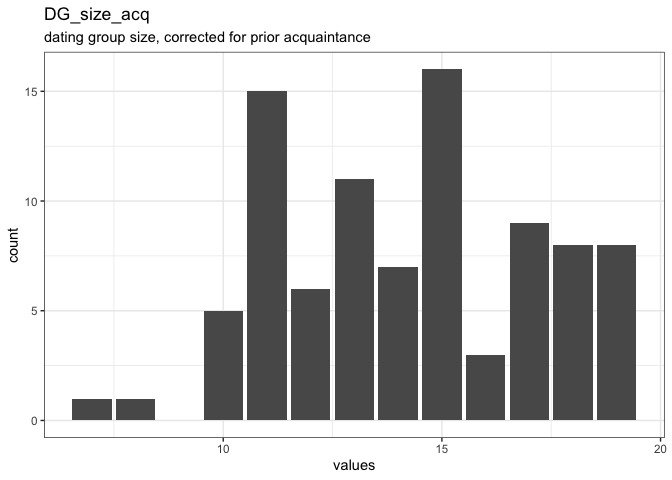

0 missing values.

#### Summary statistics

| name | label | data_type | n_missing | complete_rate | min | median | max | mean | sd | hist | format.spss | display_width |
| --- | --- | --- | --- | --- | --- | --- | --- | --- | --- | --- | --- | --- |
| DG_size_acq | dating group size, corrected for prior acquaintance | numeric | 0 | 1 | 7 | 14 | 19 | 14.22222 | 2.936702 | ▁▆▇▆▇ | F8.0 | 11 |

### age

age

#### Distribution

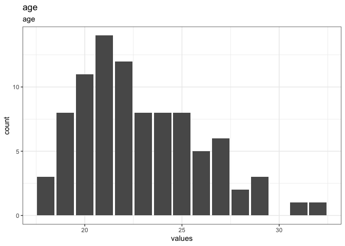

0 missing values.

#### Summary statistics

| name | label | data_type | n_missing | complete_rate | min | median | max | mean | sd | hist | format.spss | display_width |
| --- | --- | --- | --- | --- | --- | --- | --- | --- | --- | --- | --- | --- |
| age | age | numeric | 0 | 1 | 18 | 22 | 32 | 22.86667 | 3.094758 | ▅▇▅▂▁ | F3.0 | 5 |

### sex

sex

#### Distribution

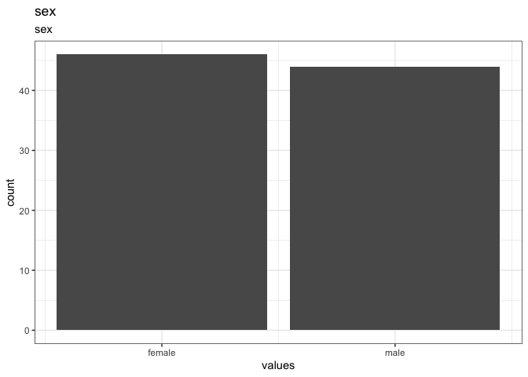

0 missing values.

#### Summary statistics

| name | label | data_type | n_missing | complete_rate | min | median | max | mean | sd | hist | format.spss | display_width |
| --- | --- | --- | --- | --- | --- | --- | --- | --- | --- | --- | --- | --- |
| sex | sex | numeric | 0 | 1 | 1 | 1 | 2 | 1.488889 | 0.502677 | ▇▁▁▁▇ | F1.0 | 5 |

#### Value labels

| name | value |
| --- | --- |
| female | 1 |
| male | 2 |

Response choices

### height

height

#### Distribution

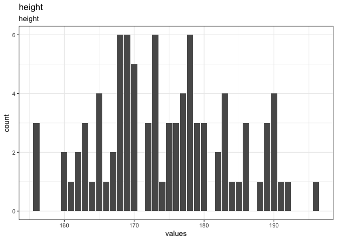

0 missing values.

#### Summary statistics

| name | label | data_type | n_missing | complete_rate | min | median | max | mean | sd | hist | format.spss | display_width |
| --- | --- | --- | --- | --- | --- | --- | --- | --- | --- | --- | --- | --- |
| height | height | numeric | 0 | 1 | 156 | 174 | 196 | 174.5444 | 9.26169 | ▃▇▇▃▃ | F3.0 | 5 |

### weight

weight

#### Distribution

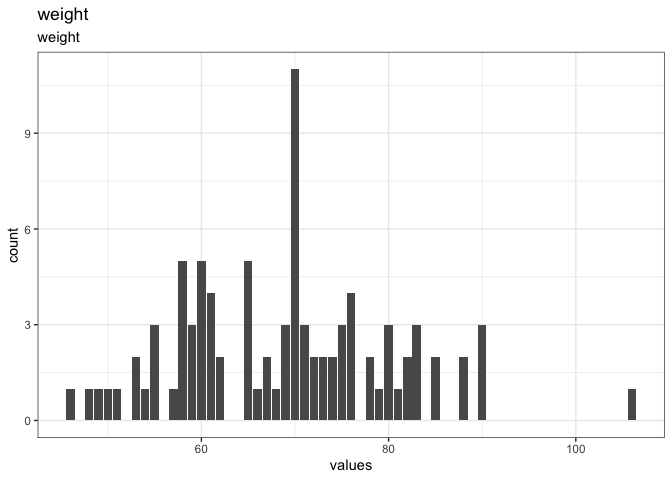

0 missing values.

#### Summary statistics

| name | label | data_type | n_missing | complete_rate | min | median | max | mean | sd | hist | format.spss | display_width |
| --- | --- | --- | --- | --- | --- | --- | --- | --- | --- | --- | --- | --- |
| weight | weight | numeric | 0 | 1 | 46 | 70 | 106 | 68.91111 | 11.28452 | ▃▇▆▂▁ | F3.0 | 5 |

### relStat

relationship status

#### Distribution

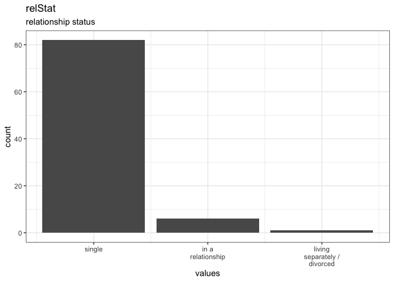

1 missing values.

#### Summary statistics

| name | label | data_type | n_missing | complete_rate | min | median | max | mean | sd | hist | format.spss | display_width |
| --- | --- | --- | --- | --- | --- | --- | --- | --- | --- | --- | --- | --- |
| relStat | relationship status | numeric | 1 | 0.9888889 | 1 | 1 | 3 | 1.089888 | 0.3247534 | ▇▁▁▁▁ | F8.0 | 10 |

#### Value labels

| name | value |
| --- | --- |
| single | 1 |
| in a relationship | 2 |
| living separately / divorced | 3 |

Response choices

### relStat_other

other relationship status

#### Distribution

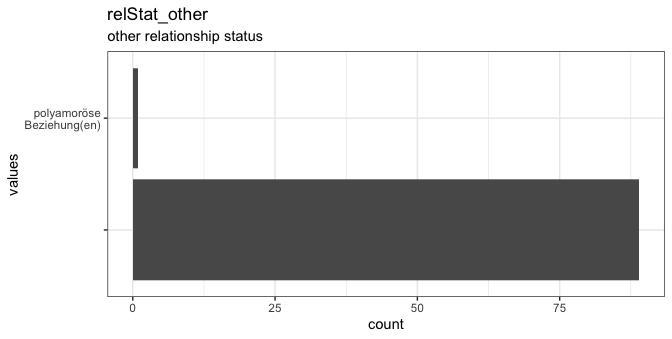

0 missing values.

#### Summary statistics

| name | label | data_type | n_missing | complete_rate | n_unique | empty | min | max | whitespace | format.spss | display_width |
| --- | --- | --- | --- | --- | --- | --- | --- | --- | --- | --- | --- |
| relStat_other | other relationship status | character | 0 | 1 | 2 | 89 | 0 | 25 | 0 | A234 | 5 |

### education

highest educational attainment

#### Distribution

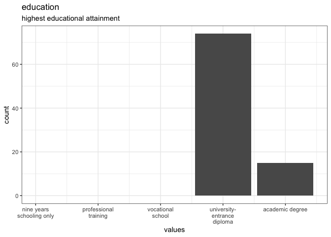

1 missing values.

#### Summary statistics

| name | label | data_type | n_missing | complete_rate | min | median | max | mean | sd | hist | format.spss | display_width |
| --- | --- | --- | --- | --- | --- | --- | --- | --- | --- | --- | --- | --- |
| education | highest educational attainment | numeric | 1 | 0.9888889 | 4 | 4 | 5 | 4.168539 | 0.3764655 | ▇▁▁▁▂ | F1.0 | 5 |

#### Value labels

| name | value |
| --- | --- |
| nine years schooling only | 1 |
| professional training | 2 |
| vocational school | 3 |
| university-entrance diploma | 4 |
| academic degree | 5 |

Response choices

### contracept

hormonal contraception

#### Distribution

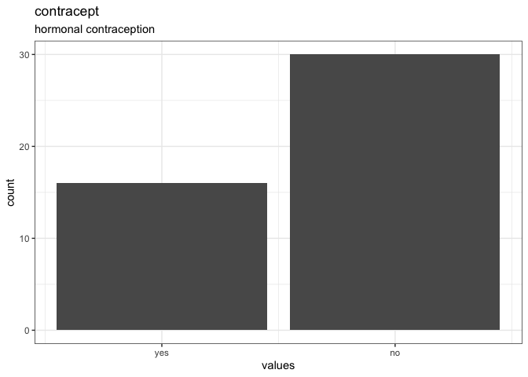

44 missing values.

#### Summary statistics

| name | label | data_type | n_missing | complete_rate | min | median | max | mean | sd | hist | format.spss | display_width |
| --- | --- | --- | --- | --- | --- | --- | --- | --- | --- | --- | --- | --- |
| contracept | hormonal contraception | numeric | 44 | 0.5111111 | 1 | 2 | 2 | 1.652174 | 0.4815434 | ▅▁▁▁▇ | F1.0 | 5 |

#### Value labels

| name | value |
| --- | --- |
| yes | 1 |
| no | 2 |

Response choices

### date

past experience with speed dating

#### Distribution

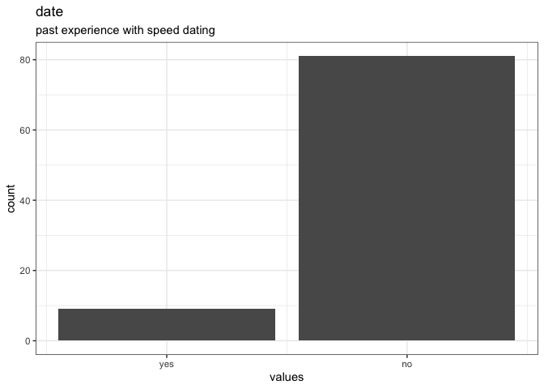

0 missing values.

#### Summary statistics

| name | label | data_type | n_missing | complete_rate | min | median | max | mean | sd | hist | format.spss | display_width |
| --- | --- | --- | --- | --- | --- | --- | --- | --- | --- | --- | --- | --- |
| date | past experience with speed dating | numeric | 0 | 1 | 1 | 2 | 2 | 1.9 | 0.3016807 | ▁▁▁▁▇ | F1.0 | 5 |

#### Value labels

| name | value |
| --- | --- |
| yes | 1 |
| no | 2 |

Response choices

### NPI_avg

narcissistic personality inventory - average

#### Distribution

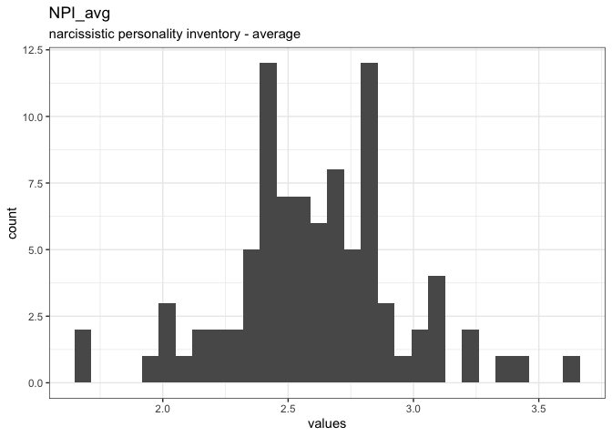

0 missing values.

#### Summary statistics

| name | label | data_type | n_missing | complete_rate | min | median | max | mean | sd | hist | format.spss | display_width |
| --- | --- | --- | --- | --- | --- | --- | --- | --- | --- | --- | --- | --- |
| NPI_avg | narcissistic personality inventory - average | numeric | 0 | 1 | 1.7 | 2.6 | 3.6 | 2.611944 | 0.3468807 | ▁▅▇▂▁ | F8.2 | 10 |

### SRP_avg

self-report psychopathy scale - average

#### Distribution

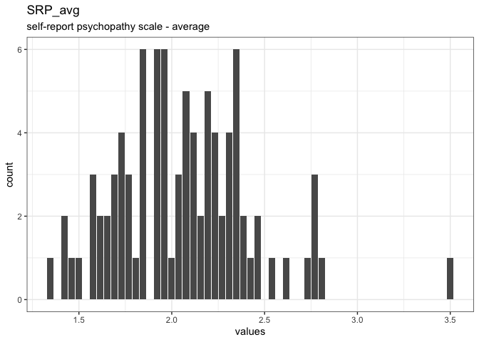

0 missing values.

#### Summary statistics

| name | label | data_type | n_missing | complete_rate | min | median | max | mean | sd | hist | format.spss | display_width |
| --- | --- | --- | --- | --- | --- | --- | --- | --- | --- | --- | --- | --- |
| SRP_avg | self-report psychopathy scale - average | numeric | 0 | 1 | 1.3 | 2.1 | 3.5 | 2.061539 | 0.3653243 | ▅▇▅▁▁ | F8.2 | 10 |

### MACHIV_avg

mach-iv - average

#### Distribution

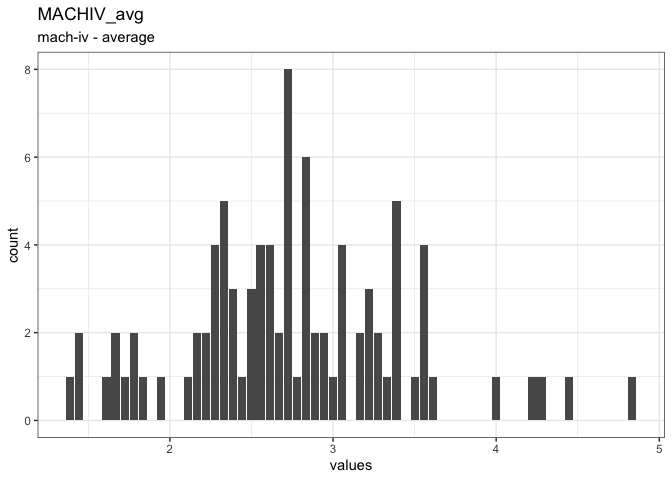

0 missing values.

#### Summary statistics

| name | label | data_type | n_missing | complete_rate | min | median | max | mean | sd | hist | format.spss | display_width |
| --- | --- | --- | --- | --- | --- | --- | --- | --- | --- | --- | --- | --- |
| MACHIV_avg | mach-iv - average | numeric | 0 | 1 | 1.4 | 2.7 | 4.8 | 2.749383 | 0.6652734 | ▂▇▆▂▁ | F8.2 | 12 |

### BFI_N_avg

big five inventory: neuroticism - average

#### Distribution

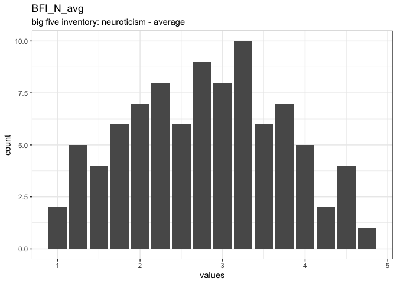

0 missing values.

#### Summary statistics

| name | label | data_type | n_missing | complete_rate | min | median | max | mean | sd | hist | format.spss | display_width |
| --- | --- | --- | --- | --- | --- | --- | --- | --- | --- | --- | --- | --- |
| BFI_N_avg | big five inventory: neuroticism - average | numeric | 0 | 1 | 1 | 2.8 | 4.8 | 2.794444 | 0.934346 | ▅▆▇▅▂ | F8.2 | 11 |

### BFI_E_avg

big five inventory: extraversion - average

#### Distribution

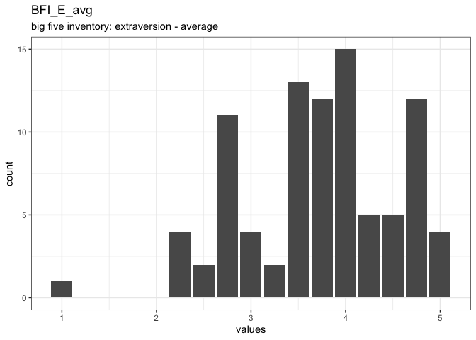

0 missing values.

#### Summary statistics

| name | label | data_type | n_missing | complete_rate | min | median | max | mean | sd | hist | format.spss | display_width |
| --- | --- | --- | --- | --- | --- | --- | --- | --- | --- | --- | --- | --- |
| BFI_E_avg | big five inventory: extraversion - average | numeric | 0 | 1 | 1 | 3.8 | 5 | 3.722222 | 0.8032977 | ▁▁▃▇▅ | F8.2 | 11 |

### BFI_O_avg

big five inventory: openness - average

#### Distribution

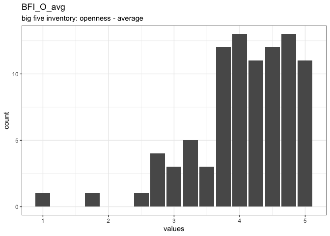

0 missing values.

#### Summary statistics

| name | label | data_type | n_missing | complete_rate | min | median | max | mean | sd | hist | format.spss | display_width |
| --- | --- | --- | --- | --- | --- | --- | --- | --- | --- | --- | --- | --- |
| BFI_O_avg | big five inventory: openness - average | numeric | 0 | 1 | 1 | 4.2 | 5 | 4.072222 | 0.7599938 | ▁▁▂▅▇ | F8.2 | 11 |

### BFI_A_avg

big five inventory: agreeableness - average

#### Distribution

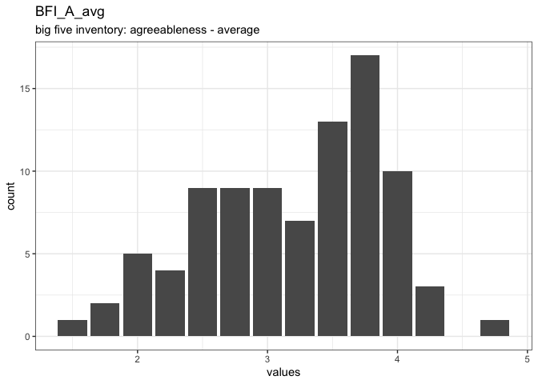

0 missing values.

#### Summary statistics

| name | label | data_type | n_missing | complete_rate | min | median | max | mean | sd | hist | format.spss | display_width |
| --- | --- | --- | --- | --- | --- | --- | --- | --- | --- | --- | --- | --- |
| BFI_A_avg | big five inventory: agreeableness - average | numeric | 0 | 1 | 1.5 | 3.2 | 4.8 | 3.197222 | 0.6945761 | ▂▅▃▇▁ | F8.2 | 11 |

### BFI_C_avg

big five inventory: conscientiousness - average

#### Distribution

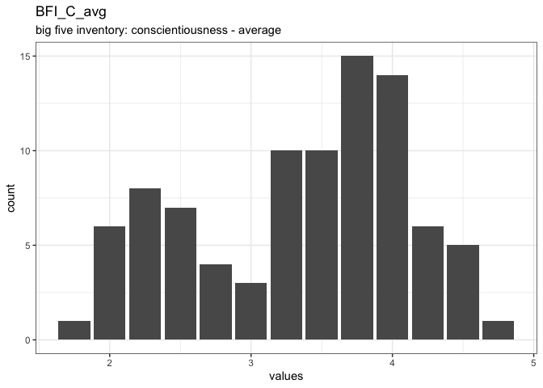

0 missing values.

#### Summary statistics

| name | label | data_type | n_missing | complete_rate | min | median | max | mean | sd | hist | format.spss | display_width |
| --- | --- | --- | --- | --- | --- | --- | --- | --- | --- | --- | --- | --- |
| BFI_C_avg | big five inventory: conscientiousness - average | numeric | 0 | 1 | 1.8 | 3.5 | 4.8 | 3.352778 | 0.7651966 | ▅▃▆▇▃ | F8.2 | 11 |

### PA_R1

physical attractiveness - rater1(f)

#### Distribution

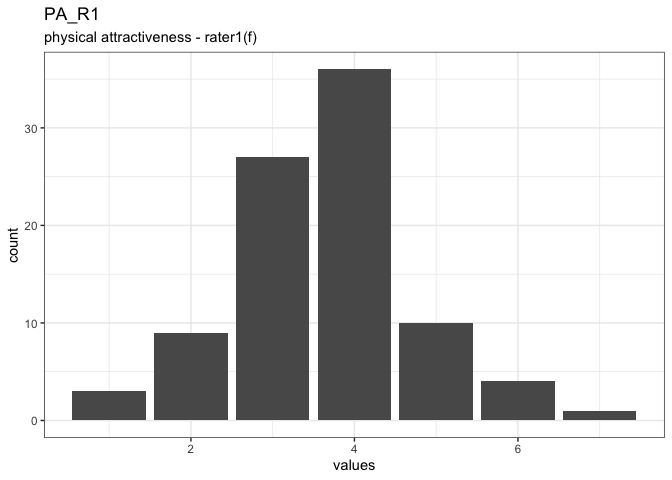

0 missing values.

#### Summary statistics

| name | label | data_type | n_missing | complete_rate | min | median | max | mean | sd | hist | format.spss | display_width |
| --- | --- | --- | --- | --- | --- | --- | --- | --- | --- | --- | --- | --- |
| PA_R1 | physical attractiveness - rater1(f) | numeric | 0 | 1 | 1 | 4 | 7 | 3.633333 | 1.126294 | ▂▆▇▂▁ | F8.2 | 14 |

### PA_R2

physical attractiveness - rater2(f)

#### Distribution

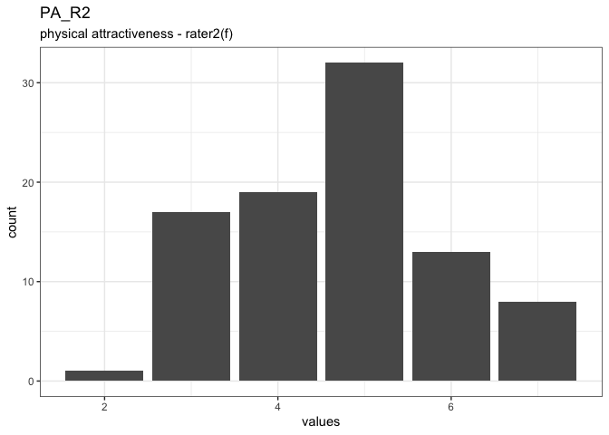

0 missing values.

#### Summary statistics

| name | label | data_type | n_missing | complete_rate | min | median | max | mean | sd | hist | format.spss |
| --- | --- | --- | --- | --- | --- | --- | --- | --- | --- | --- | --- |
| PA_R2 | physical attractiveness - rater2(f) | numeric | 0 | 1 | 2 | 5 | 7 | 4.7 | 1.22199 | ▅▅▇▃▂ | F8.2 |

### PA_R3

physical attractiveness - rater3(m)

#### Distribution

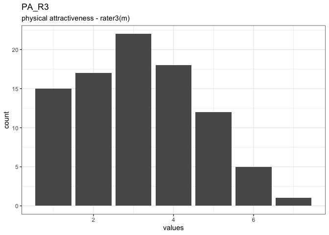

0 missing values.

#### Summary statistics

| name | label | data_type | n_missing | complete_rate | min | median | max | mean | sd | hist | format.spss |
| --- | --- | --- | --- | --- | --- | --- | --- | --- | --- | --- | --- |
| PA_R3 | physical attractiveness - rater3(m) | numeric | 0 | 1 | 1 | 3 | 7 | 3.155556 | 1.505877 | ▇▆▅▃▂ | F8.2 |

### PA_R4

physical attractiveness - rater4(m)

#### Distribution

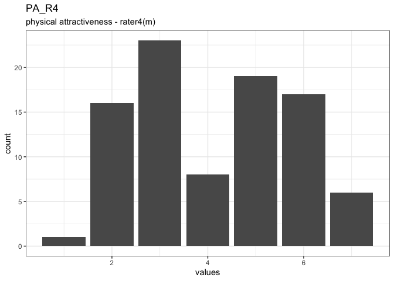

0 missing values.

#### Summary statistics

| name | label | data_type | n_missing | complete_rate | min | median | max | mean | sd | hist | format.spss |
| --- | --- | --- | --- | --- | --- | --- | --- | --- | --- | --- | --- |
| PA_R4 | physical attractiveness - rater4(m) | numeric | 0 | 1 | 1 | 4 | 7 | 4.144444 | 1.625368 | ▆▇▃▆▇ | F8.2 |

### PA_avg

physical attractiveness - average

#### Distribution

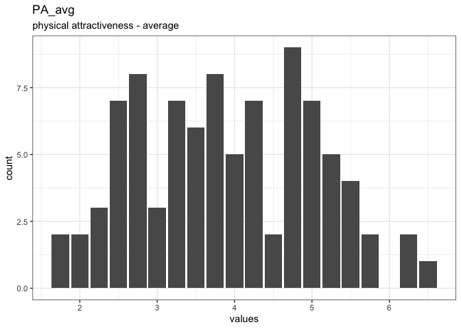

0 missing values.

#### Summary statistics

| name | label | data_type | n_missing | complete_rate | min | median | max | mean | sd | hist | format.spss | display_width |
| --- | --- | --- | --- | --- | --- | --- | --- | --- | --- | --- | --- | --- |
| PA_avg | physical attractiveness - average | numeric | 0 | 1 | 1.8 | 3.8 | 6.5 | 3.908333 | 1.141929 | ▅▇▇▇▂ | F8.2 | 19 |

### BMI

body mass index

#### Distribution

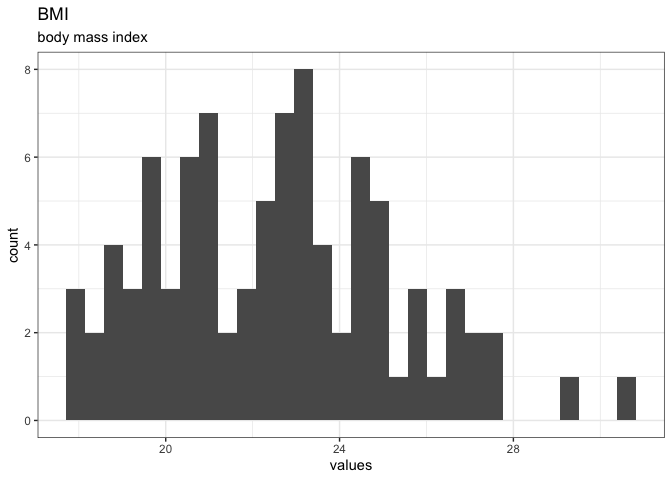

0 missing values.

#### Summary statistics

| name | label | data_type | n_missing | complete_rate | min | median | max | mean | sd | hist | format.spss | display_width |
| --- | --- | --- | --- | --- | --- | --- | --- | --- | --- | --- | --- | --- |
| BMI | body mass index | numeric | 0 | 1 | 18 | 23 | 31 | 22.54685 | 2.753195 | ▆▇▆▃▁ | F8.2 | 10 |

### SOI_R_B_avg

sociosexual orientation inventory revised: behavior - average

#### Distribution

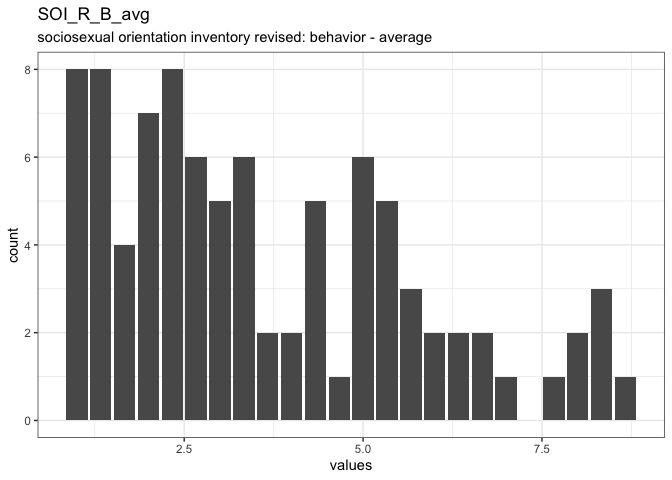

0 missing values.

#### Summary statistics

| name | label | data_type | n_missing | complete_rate | min | median | max | mean | sd | hist | format.spss | display_width |
| --- | --- | --- | --- | --- | --- | --- | --- | --- | --- | --- | --- | --- |
| SOI_R_B_avg | sociosexual orientation inventory revised: behavior - average | numeric | 0 | 1 | 1 | 3 | 8.7 | 3.62963 | 2.111998 | ▇▅▃▂▂ | F8.2 | 16 |

### SOI_R_A_avg

sociosexual orientation inventory revised: attitude - average

#### Distribution

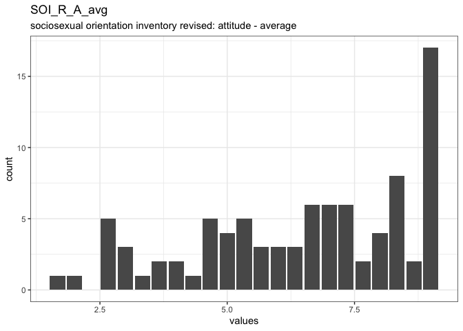

0 missing values.

#### Summary statistics

| name | label | data_type | n_missing | complete_rate | min | median | max | mean | sd | hist | format.spss | display_width |
| --- | --- | --- | --- | --- | --- | --- | --- | --- | --- | --- | --- | --- |
| SOI_R_A_avg | sociosexual orientation inventory revised: attitude - average | numeric | 0 | 1 | 1.7 | 6.8 | 9 | 6.481482 | 2.100539 | ▂▂▅▅▇ | F8.2 | 17 |

### SOI_R_D_avg

sociosexual orientation inventory revised: desire - average

#### Distribution

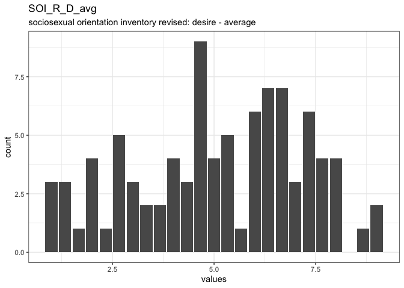

0 missing values.

#### Summary statistics

| name | label | data_type | n_missing | complete_rate | min | median | max | mean | sd | hist | format.spss | display_width |
| --- | --- | --- | --- | --- | --- | --- | --- | --- | --- | --- | --- | --- |
| SOI_R_D_avg | sociosexual orientation inventory revised: desire - average | numeric | 0 | 1 | 1 | 5.3 | 9 | 5.111111 | 2.092135 | ▃▅▆▇▃ | F8.2 | 15 |

### TargEff__choice_relFrequ_acq {#TargEff__choice_relFrequ_acq .tabset}

SRM target effect: actual choice

#### Distribution

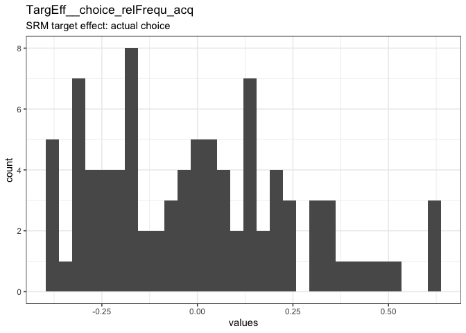

0 missing values.

#### Summary statistics

| name | label | data_type | n_missing | complete_rate | min | median | max | mean | sd | hist | format.spss | display_width |
| --- | --- | --- | --- | --- | --- | --- | --- | --- | --- | --- | --- | --- |
| TargEff__choice_relFrequ_acq | SRM target effect: actual choice | numeric | 0 | 1 | -0.39 | -0.0056 | 0.61 | 1.82e-05 | 0.257597 | ▇▇▇▃▂ | F8.2 | 34 |

### TargEff__FS_avg_acq {#TargEff__FS_avg_acq .tabset}

SRM target effect: friendship

#### Distribution

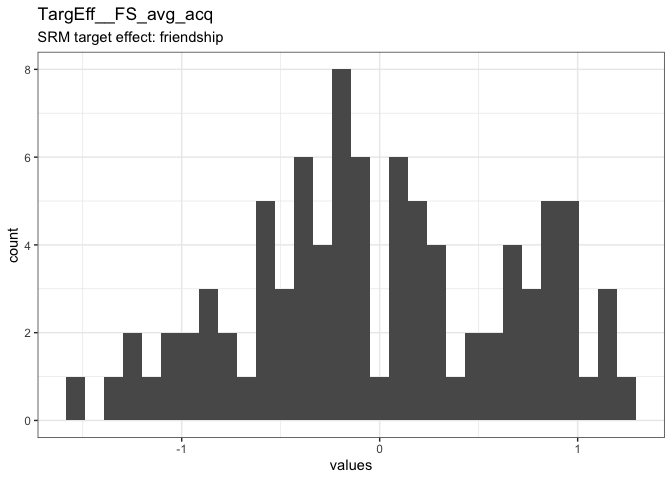

0 missing values.

#### Summary statistics

| name | label | data_type | n_missing | complete_rate | min | median | max | mean | sd | hist | format.spss | display_width |
| --- | --- | --- | --- | --- | --- | --- | --- | --- | --- | --- | --- | --- |
| TargEff__FS_avg_acq | SRM target effect: friendship | numeric | 0 | 1 | -1.5 | -0.065 | 1.2 | 2.51e-05 | 0.6740996 | ▂▃▇▅▅ | F8.2 | 29 |

### TargEff__ONS_avg_acq {#TargEff__ONS_avg_acq .tabset}

SRM target effect: one night stand

#### Distribution

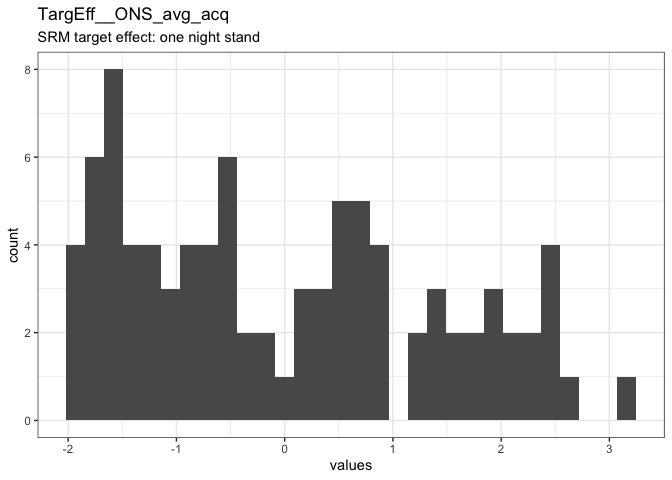

0 missing values.

#### Summary statistics

| name | label | data_type | n_missing | complete_rate | min | median | max | mean | sd | hist | format.spss | display_width |
| --- | --- | --- | --- | --- | --- | --- | --- | --- | --- | --- | --- | --- |
| TargEff__ONS_avg_acq | SRM target effect: one night stand | numeric | 0 | 1 | -2 | -0.22 | 3.1 | 2.23e-05 | 1.417459 | ▇▅▆▃▃ | F8.2 | 21 |

### TargEff__BC_avg_acq {#TargEff__BC_avg_acq .tabset}

SRM target effect: booty call

#### Distribution

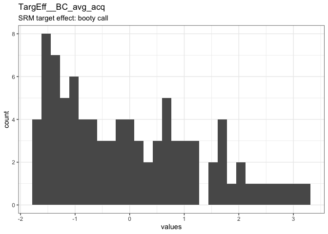

0 missing values.

#### Summary statistics

| name | label | data_type | n_missing | complete_rate | min | median | max | mean | sd | hist | format.spss | display_width |
| --- | --- | --- | --- | --- | --- | --- | --- | --- | --- | --- | --- | --- |
| TargEff__BC_avg_acq | SRM target effect: booty call | numeric | 0 | 1 | -1.6 | -0.13 | 3.3 | -4.1e-05 | 1.32644 | ▇▃▃▂▁ | F8.2 | 28 |

### TargEff__FWB_avg_acq {#TargEff__FWB_avg_acq .tabset}

SRM target effect: friends-with-benefits

#### Distribution

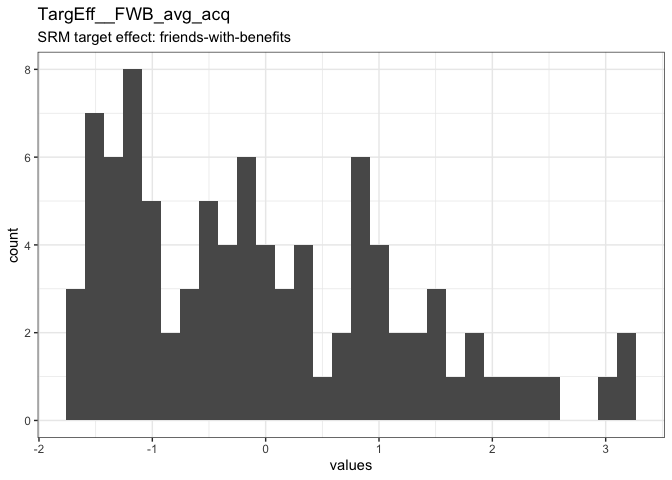

0 missing values.

#### Summary statistics

| name | label | data_type | n_missing | complete_rate | min | median | max | mean | sd | hist | format.spss | display_width |
| --- | --- | --- | --- | --- | --- | --- | --- | --- | --- | --- | --- | --- |
| TargEff__FWB_avg_acq | SRM target effect: friends-with-benefits | numeric | 0 | 1 | -1.6 | -0.16 | 3.2 | -2.81e-05 | 1.244604 | ▇▆▅▂▁ | F8.2 | 30 |

### TargEff__STR_avg_acq {#TargEff__STR_avg_acq .tabset}

SRM target effect: short-term relationship (aggregated)

#### Distribution

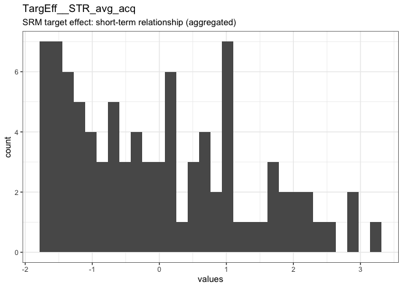

0 missing values.

#### Summary statistics

| name | label | data_type | n_missing | complete_rate | min | median | max | mean | sd | hist | format.spss | display_width |
| --- | --- | --- | --- | --- | --- | --- | --- | --- | --- | --- | --- | --- |
| TargEff__STR_avg_acq | SRM target effect: short-term relationship (aggregated) | numeric | 0 | 1 | -1.7 | -0.23 | 3.2 | -1.56e-05 | 1.318697 | ▇▅▅▂▂ | F8.2 | 13 |

### TargEff__LTR_avg_acq {#TargEff__LTR_avg_acq .tabset}

SRM target effect: long-term relationship

#### Distribution

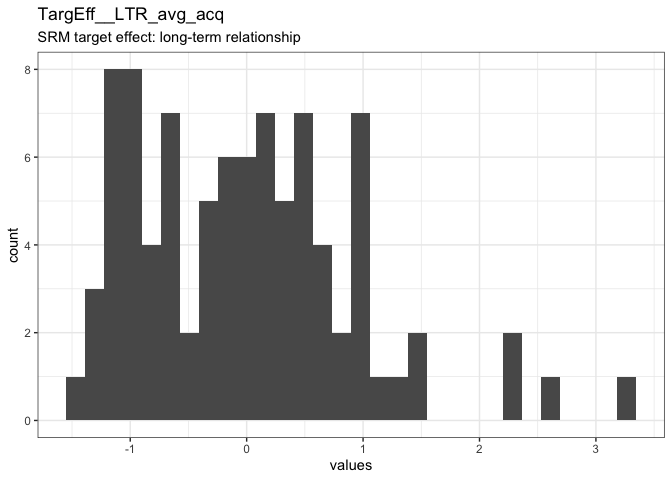

0 missing values.

#### Summary statistics

| name | label | data_type | n_missing | complete_rate | min | median | max | mean | sd | hist | format.spss | display_width |
| --- | --- | --- | --- | --- | --- | --- | --- | --- | --- | --- | --- | --- |
| TargEff__LTR_avg_acq | SRM target effect: long-term relationship | numeric | 0 | 1 | -1.4 | -0.066 | 3.3 | -1.73e-05 | 0.9444001 | ▇▇▅▁▁ | F8.2 | 27 |

### TargEff__PA_avg_acq {#TargEff__PA_avg_acq .tabset}

SRM target effect: physical attractiveness

#### Distribution

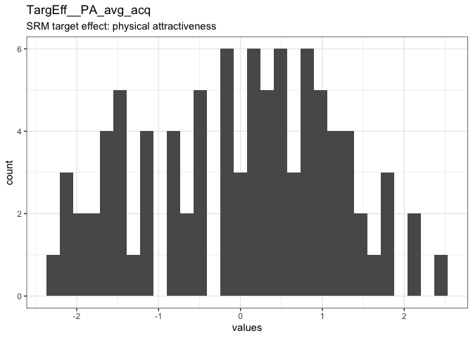

0 missing values.

#### Summary statistics

| name | label | data_type | n_missing | complete_rate | min | median | max | mean | sd | hist | format.spss | display_width |
| --- | --- | --- | --- | --- | --- | --- | --- | --- | --- | --- | --- | --- |
| TargEff__PA_avg_acq | SRM target effect: physical attractiveness | numeric | 0 | 1 | -2.2 | 0.22 | 2.5 | -2.62e-05 | 1.177495 | ▅▅▇▆▂ | F8.2 | 28 |

### TargEff__Like_avg_acq {#TargEff__Like_avg_acq .tabset}

SRM target effect: likeability

#### Distribution

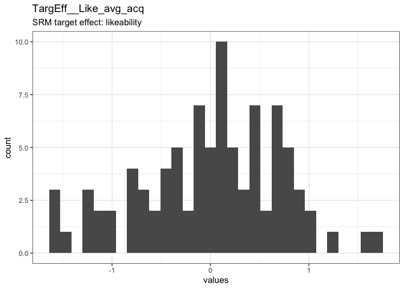

0 missing values.

#### Summary statistics

| name | label | data_type | n_missing | complete_rate | min | median | max | mean | sd | hist | format.spss | display_width |
| --- | --- | --- | --- | --- | --- | --- | --- | --- | --- | --- | --- | --- |
| TargEff__Like_avg_acq | SRM target effect: likeability | numeric | 0 | 1 | -1.6 | 0.092 | 1.7 | 4.39e-05 | 0.7112554 | ▃▅▇▆▁ | F8.2 | 31 |

### TargEff__Int_avg_acq {#TargEff__Int_avg_acq .tabset}

SRM target effect: intelligence

#### Distribution

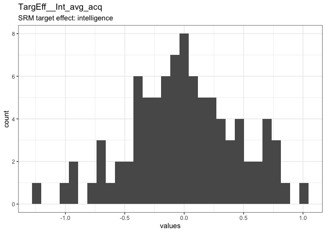

0 missing values.

#### Summary statistics

| name | label | data_type | n_missing | complete_rate | min | median | max | mean | sd | hist | format.spss | display_width |
| --- | --- | --- | --- | --- | --- | --- | --- | --- | --- | --- | --- | --- |
| TargEff__Int_avg_acq | SRM target effect: intelligence | numeric | 0 | 1 | -1.2 | -0.0082 | 1 | 2.54e-05 | 0.4567633 | ▁▃▇▆▃ | F8.2 | 29 |

### TargEff__FIPI_N_avg_acq {#TargEff__FIPI_N_avg_acq .tabset}

SRM target effect: neuroticism

#### Distribution

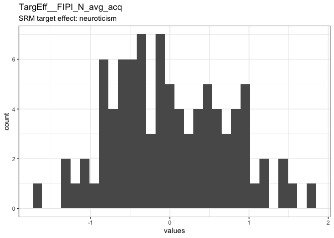

0 missing values.

#### Summary statistics

| name | label | data_type | n_missing | complete_rate | min | median | max | mean | sd | hist | format.spss | display_width |
| --- | --- | --- | --- | --- | --- | --- | --- | --- | --- | --- | --- | --- |
| TargEff__FIPI_N_avg_acq | SRM target effect: neuroticism | numeric | 0 | 1 | -1.7 | -0.093 | 1.8 | 1.61e-05 | 0.7246828 | ▂▇▆▆▂ | F8.2 | 28 |

### TargEff__FIPI_E_avg_acq {#TargEff__FIPI_E_avg_acq .tabset}

SRM target effect: extraversion

#### Distribution

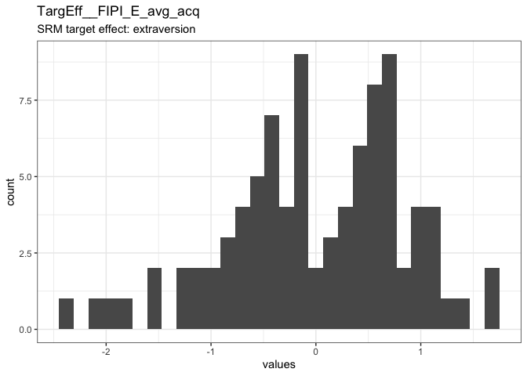

0 missing values.

#### Summary statistics

| name | label | data_type | n_missing | complete_rate | min | median | max | mean | sd | hist | format.spss | display_width |
| --- | --- | --- | --- | --- | --- | --- | --- | --- | --- | --- | --- | --- |
| TargEff__FIPI_E_avg_acq | SRM target effect: extraversion | numeric | 0 | 1 | -2.4 | 0.00083 | 1.7 | -1.38e-05 | 0.8477838 | ▁▂▇▇▃ | F8.2 | 28 |

### TargEff__FIPI_O_avg_acq {#TargEff__FIPI_O_avg_acq .tabset}

SRM target effect: openness

#### Distribution

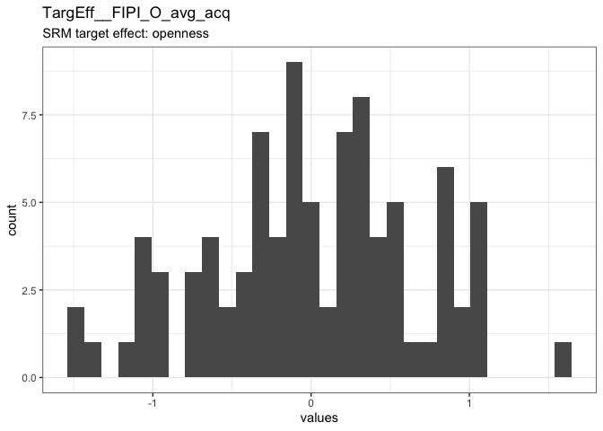

0 missing values.

#### Summary statistics

| name | label | data_type | n_missing | complete_rate | min | median | max | mean | sd | hist | format.spss | display_width |
| --- | --- | --- | --- | --- | --- | --- | --- | --- | --- | --- | --- | --- |
| TargEff__FIPI_O_avg_acq | SRM target effect: openness | numeric | 0 | 1 | -1.5 | -0.032 | 1.6 | 5.2e-06 | 0.6533151 | ▂▅▇▅▂ | F8.2 | 28 |

### TargEff__FIPI_A_avg_acq {#TargEff__FIPI_A_avg_acq .tabset}

SRM target effect: agreeableness

#### Distribution

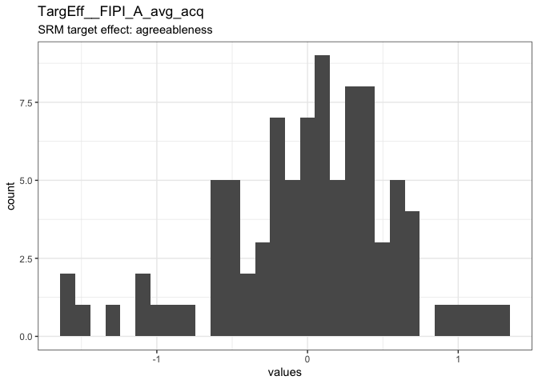

0 missing values.

#### Summary statistics

| name | label | data_type | n_missing | complete_rate | min | median | max | mean | sd | hist | format.spss | display_width |
| --- | --- | --- | --- | --- | --- | --- | --- | --- | --- | --- | --- | --- |
| TargEff__FIPI_A_avg_acq | SRM target effect: agreeableness | numeric | 0 | 1 | -1.6 | 0.076 | 1.3 | -4.46e-05 | 0.5824646 | ▂▃▇▇▂ | F8.2 | 31 |

### TargEff__FIPI_C_avg_acq {#TargEff__FIPI_C_avg_acq .tabset}

SRM target effect: conscientiousness

#### Distribution

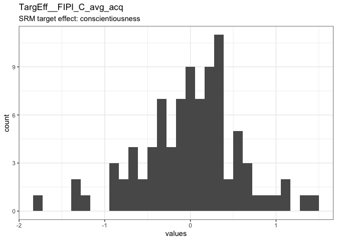

0 missing values.

#### Summary statistics

| name | label | data_type | n_missing | complete_rate | min | median | max | mean | sd | hist | format.spss | display_width |
| --- | --- | --- | --- | --- | --- | --- | --- | --- | --- | --- | --- | --- |
| TargEff__FIPI_C_avg_acq | SRM target effect: conscientiousness | numeric | 0 | 1 | -1.8 | 0.03 | 1.4 | -3.87e-05 | 0.5820808 | ▁▂▇▇▂ | F8.2 | 29 |

### PercEff__choice_relFrequ_acq {#PercEff__choice_relFrequ_acq .tabset}

SRM perceiver effect: actual choice

#### Distribution

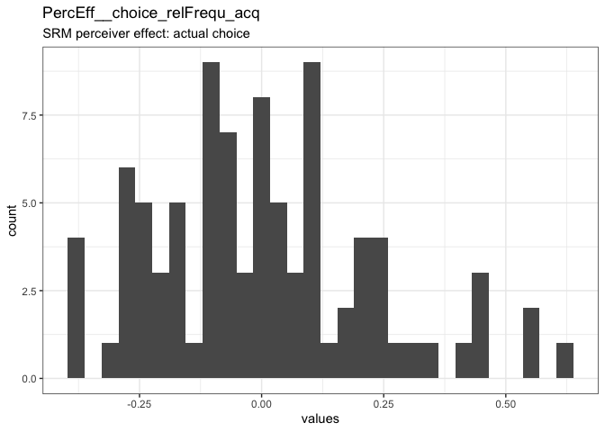

0 missing values.

#### Summary statistics

| name | label | data_type | n_missing | complete_rate | min | median | max | mean | sd | hist | format.spss | display_width |
| --- | --- | --- | --- | --- | --- | --- | --- | --- | --- | --- | --- | --- |
| PercEff__choice_relFrequ_acq | SRM perceiver effect: actual choice | numeric | 0 | 1 | -0.38 | -0.016 | 0.62 | 3.98e-05 | 0.2266172 | ▆▇▆▂▂ | F8.2 | 34 |

### PercEff__FS_avg_acq {#PercEff__FS_avg_acq .tabset}

SRM perceiver effect: friendship

#### Distribution

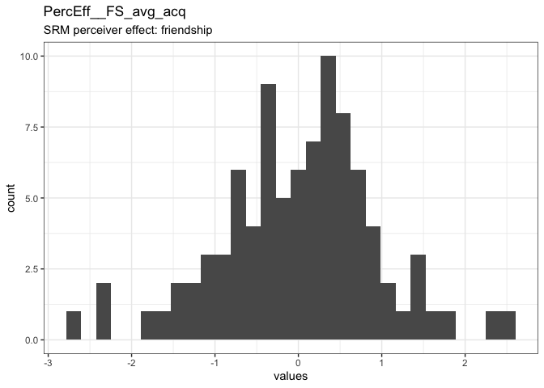

0 missing values.

#### Summary statistics

| name | label | data_type | n_missing | complete_rate | min | median | max | mean | sd | hist | format.spss | display_width |
| --- | --- | --- | --- | --- | --- | --- | --- | --- | --- | --- | --- | --- |
| PercEff__FS_avg_acq | SRM perceiver effect: friendship | numeric | 0 | 1 | -2.7 | 0.096 | 2.5 | -3.72e-05 | 0.9577896 | ▁▃▇▆▁ | F8.2 | 29 |

### PercEff__ONS_avg_acq {#PercEff__ONS_avg_acq .tabset}

SRM perceiver effect: one night stand

#### Distribution

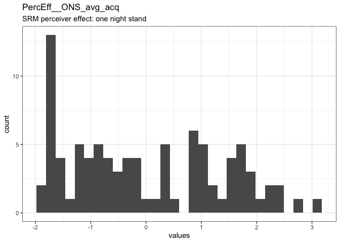

0 missing values.

#### Summary statistics

| name | label | data_type | n_missing | complete_rate | min | median | max | mean | sd | hist | format.spss | display_width |
| --- | --- | --- | --- | --- | --- | --- | --- | --- | --- | --- | --- | --- |
| PercEff__ONS_avg_acq | SRM perceiver effect: one night stand | numeric | 0 | 1 | -2 | -0.23 | 3 | 1.57e-05 | 1.377661 | ▇▆▅▅▂ | F8.2 | 21 |

### PercEff__BC_avg_acq {#PercEff__BC_avg_acq .tabset}

SRM perceiver effect: booty call

#### Distribution

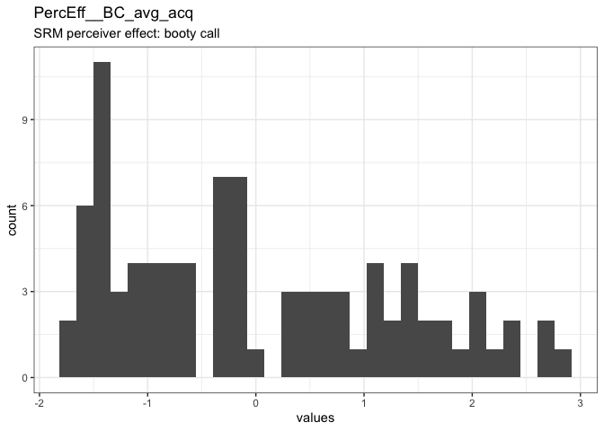

0 missing values.

#### Summary statistics

| name | label | data_type | n_missing | complete_rate | min | median | max | mean | sd | hist | format.spss | display_width |
| --- | --- | --- | --- | --- | --- | --- | --- | --- | --- | --- | --- | --- |
| PercEff__BC_avg_acq | SRM perceiver effect: booty call | numeric | 0 | 1 | -1.8 | -0.24 | 2.8 | -1.25e-05 | 1.285049 | ▇▆▃▅▃ | F8.2 | 28 |

### PercEff__FWB_avg_acq {#PercEff__FWB_avg_acq .tabset}

SRM perceiver effect: friends-with-benefits

#### Distribution

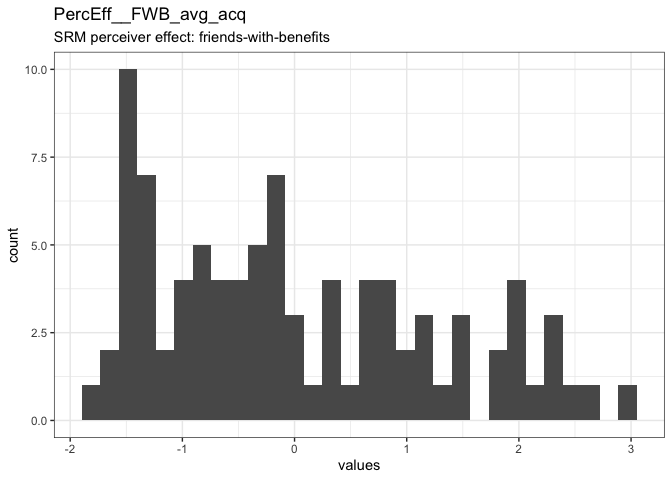

0 missing values.

#### Summary statistics

| name | label | data_type | n_missing | complete_rate | min | median | max | mean | sd | hist | format.spss | display_width |
| --- | --- | --- | --- | --- | --- | --- | --- | --- | --- | --- | --- | --- |
| PercEff__FWB_avg_acq | SRM perceiver effect: friends-with-benefits | numeric | 0 | 1 | -1.8 | -0.24 | 3 | -1.04e-05 | 1.265079 | ▇▇▅▃▂ | F8.2 | 30 |

### PercEff__STR_avg_acq {#PercEff__STR_avg_acq .tabset}

SRM perceiver effect: short-term relationship (aggregated)

#### Distribution

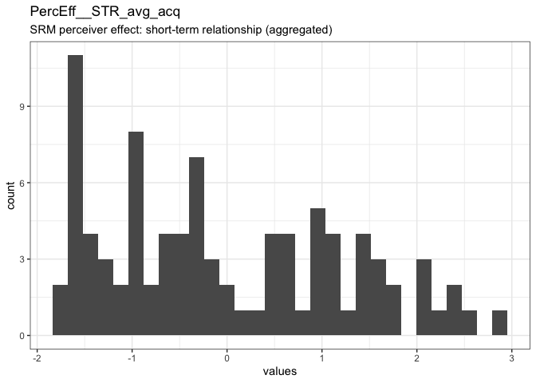

0 missing values.

#### Summary statistics

| name | label | data_type | n_missing | complete_rate | min | median | max | mean | sd | hist | format.spss | display_width |
| --- | --- | --- | --- | --- | --- | --- | --- | --- | --- | --- | --- | --- |
| PercEff__STR_avg_acq | SRM perceiver effect: short-term relationship (aggregated) | numeric | 0 | 1 | -1.8 | -0.3 | 2.8 | -2.4e-06 | 1.259888 | ▇▆▃▅▂ | F8.2 | 14 |

### PercEff__LTR_avg_acq {#PercEff__LTR_avg_acq .tabset}

SRM perceiver effect: long-term relationship

#### Distribution

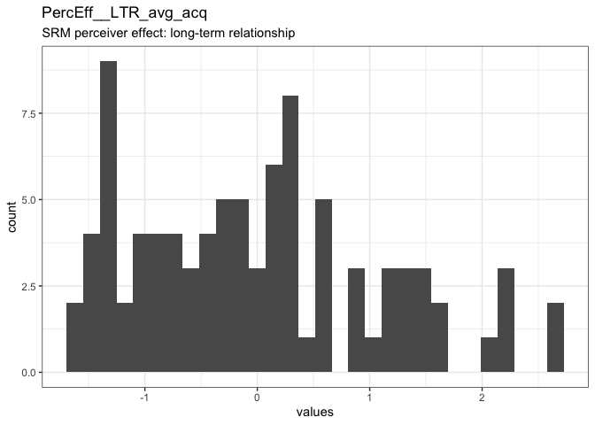

0 missing values.

#### Summary statistics

| name | label | data_type | n_missing | complete_rate | min | median | max | mean | sd | hist | format.spss | display_width |
| --- | --- | --- | --- | --- | --- | --- | --- | --- | --- | --- | --- | --- |
| PercEff__LTR_avg_acq | SRM perceiver effect: long-term relationship | numeric | 0 | 1 | -1.6 | -0.16 | 2.7 | -2e-06 | 1.084035 | ▇▆▆▃▂ | F8.2 | 27 |

### PercEff__PA_avg_acq {#PercEff__PA_avg_acq .tabset}

SRM perceiver effect: physical attractiveness

#### Distribution

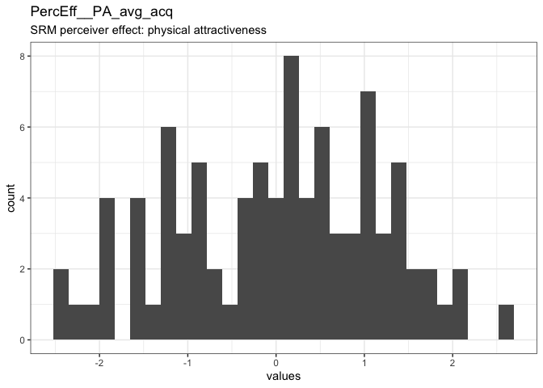

0 missing values.

#### Summary statistics

| name | label | data_type | n_missing | complete_rate | min | median | max | mean | sd | hist | format.spss | display_width |
| --- | --- | --- | --- | --- | --- | --- | --- | --- | --- | --- | --- | --- |
| PercEff__PA_avg_acq | SRM perceiver effect: physical attractiveness | numeric | 0 | 1 | -2.5 | 0.16 | 2.5 | -3.41e-05 | 1.176363 | ▃▅▇▇▂ | F8.2 | 28 |

### PercEff__Like_avg_acq {#PercEff__Like_avg_acq .tabset}

SRM perceiver effect: likeability

#### Distribution

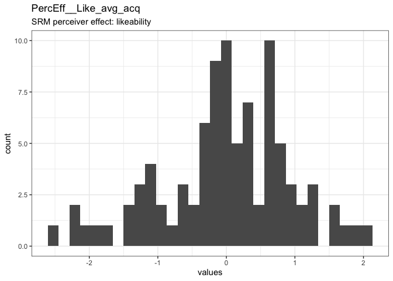

0 missing values.

#### Summary statistics

| name | label | data_type | n_missing | complete_rate | min | median | max | mean | sd | hist | format.spss | display_width |
| --- | --- | --- | --- | --- | --- | --- | --- | --- | --- | --- | --- | --- |
| PercEff__Like_avg_acq | SRM perceiver effect: likeability | numeric | 0 | 1 | -2.5 | 0.063 | 2.1 | 3.56e-05 | 0.9432916 | ▂▃▇▆▂ | F8.2 | 31 |

### PercEff__Int_avg_acq {#PercEff__Int_avg_acq .tabset}

SRM perceiver effect: intelligence

#### Distribution

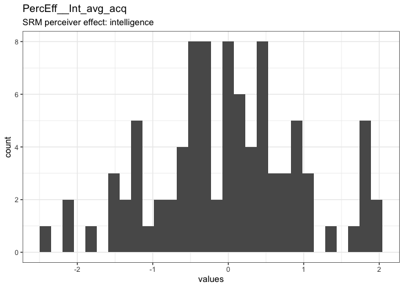

0 missing values.

#### Summary statistics

| name | label | data_type | n_missing | complete_rate | min | median | max | mean | sd | hist | format.spss | display_width |
| --- | --- | --- | --- | --- | --- | --- | --- | --- | --- | --- | --- | --- |
| PercEff__Int_avg_acq | SRM perceiver effect: intelligence | numeric | 0 | 1 | -2.4 | 0.043 | 2 | -3.88e-05 | 0.9692282 | ▂▃▇▆▂ | F8.2 | 29 |

### PercEff__FIPI_N_avg_acq {#PercEff__FIPI_N_avg_acq .tabset}

SRM perceiver effect: neuroticism

#### Distribution

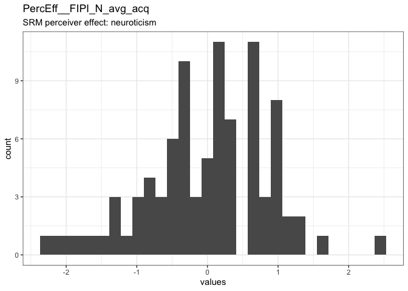

0 missing values.

#### Summary statistics

| name | label | data_type | n_missing | complete_rate | min | median | max | mean | sd | hist | format.spss | display_width |
| --- | --- | --- | --- | --- | --- | --- | --- | --- | --- | --- | --- | --- |
| PercEff__FIPI_N_avg_acq | SRM perceiver effect: neuroticism | numeric | 0 | 1 | -2.2 | 0.12 | 2.5 | 3.22e-05 | 0.8724864 | ▂▅▇▅▁ | F8.2 | 28 |

### PercEff__FIPI_E_avg_acq {#PercEff__FIPI_E_avg_acq .tabset}

SRM perceiver effect: extraversion

#### Distribution

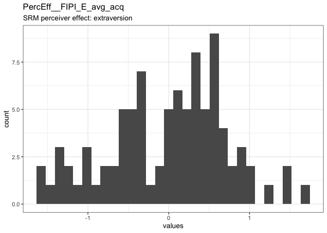

0 missing values.

#### Summary statistics

| name | label | data_type | n_missing | complete_rate | min | median | max | mean | sd | hist | format.spss | display_width |
| --- | --- | --- | --- | --- | --- | --- | --- | --- | --- | --- | --- | --- |
| PercEff__FIPI_E_avg_acq | SRM perceiver effect: extraversion | numeric | 0 | 1 | -1.6 | 0.12 | 1.7 | -4.35e-05 | 0.7303606 | ▃▆▇▇▁ | F8.2 | 28 |

### PercEff__FIPI_O_avg_acq {#PercEff__FIPI_O_avg_acq .tabset}

SRM perceiver effect: openness

#### Distribution

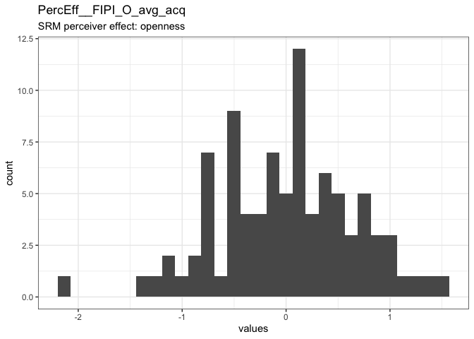

0 missing values.

#### Summary statistics

| name | label | data_type | n_missing | complete_rate | min | median | max | mean | sd | hist | format.spss | display_width |
| --- | --- | --- | --- | --- | --- | --- | --- | --- | --- | --- | --- | --- |
| PercEff__FIPI_O_avg_acq | SRM perceiver effect: openness | numeric | 0 | 1 | -2.2 | 0.064 | 1.5 | -1.9e-06 | 0.6694323 | ▁▃▇▇▂ | F8.2 | 28 |

### PercEff__FIPI_A_avg_acq {#PercEff__FIPI_A_avg_acq .tabset}

SRM perceiver effect: agreeableness

#### Distribution

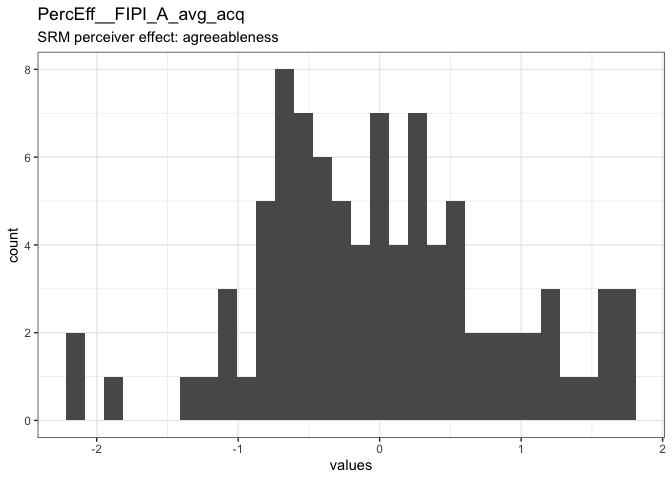

0 missing values.

#### Summary statistics

| name | label | data_type | n_missing | complete_rate | min | median | max | mean | sd | hist | format.spss | display_width |
| --- | --- | --- | --- | --- | --- | --- | --- | --- | --- | --- | --- | --- |
| PercEff__FIPI_A_avg_acq | SRM perceiver effect: agreeableness | numeric | 0 | 1 | -2.2 | -0.046 | 1.7 | 3.97e-05 | 0.8562851 | ▁▅▇▆▃ | F8.2 | 31 |

### PercEff__FIPI_C_avg_acq {#PercEff__FIPI_C_avg_acq .tabset}

SRM perceiver effect: conscientiousness

#### Distribution

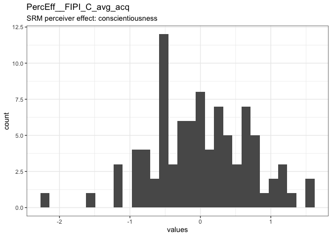

0 missing values.

#### Summary statistics

| name | label | data_type | n_missing | complete_rate | min | median | max | mean | sd | hist | format.spss | display_width |
| --- | --- | --- | --- | --- | --- | --- | --- | --- | --- | --- | --- | --- |
| PercEff__FIPI_C_avg_acq | SRM perceiver effect: conscientiousness | numeric | 0 | 1 | -2.2 | -0.0029 | 1.6 | 4.34e-05 | 0.7016471 | ▁▂▇▇▂ | F8.2 | 29 |

## Missingness report

| description | relStat | education | contracept | var_miss | n_miss |
| --- | --- | --- | --- | --- | --- |
| Missing values per variable | 1 | 1 | 44 | 46 | 46 |
| Missing values in 0 variables | 1 | 1 | 1 | 0 | 45 |
| Missing values in 1 variables | 1 | 1 | 0 | 1 | 43 |
| Missing values in 2 variables | 1 | 0 | 0 | 2 | 1 |
| Missing values in 1 variables | 0 | 1 | 1 | 1 | 1 |

## Codebook table

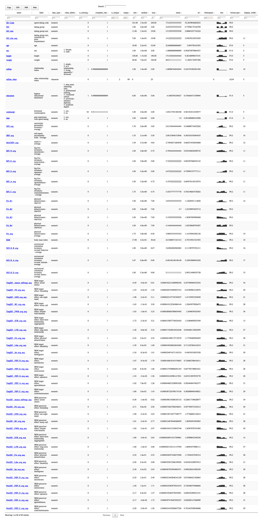

**JSON-LD metadata**

The following JSON-LD can be found by search engines, if you share this codebook publicly on the web.

```json
{
  "name": "df",
  "datePublished": "2021-03-03",
  "description": "The dataset has N=90 rows and 60 columns.\n45 rows have no missing values on any column.\n\n\n## Table of variables\nThis table contains variable names, labels, and number of missing values.\nSee the complete codebook for more.\n\n[truncated]\n\n### Note\nThis dataset was automatically described using the [codebook R package](https://rubenarslan.github.io/codebook/) (version 0.9.4.9000).",
  "keywords": ["SD_Code", "DG", "DG_size", "DG_size_acq", "age", "sex", "height", "weight", "relStat", "relStat_other", "education", "contracept", "date", "NPI_avg", "SRP_avg", "MACHIV_avg", "BFI_N_avg", "BFI_E_avg", "BFI_O_avg", "BFI_A_avg", "BFI_C_avg", "PA_R1", "PA_R2", "PA_R3", "PA_R4", "PA_avg", "BMI", "SOI_R_B_avg", "SOI_R_A_avg", "SOI_R_D_avg", "TargEff__choice_relFrequ_acq", "TargEff__FS_avg_acq", "TargEff__ONS_avg_acq", "TargEff__BC_avg_acq", "TargEff__FWB_avg_acq", "TargEff__STR_avg_acq", "TargEff__LTR_avg_acq", "TargEff__PA_avg_acq", "TargEff__Like_avg_acq", "TargEff__Int_avg_acq", "TargEff__FIPI_N_avg_acq", "TargEff__FIPI_E_avg_acq", "TargEff__FIPI_O_avg_acq", "TargEff__FIPI_A_avg_acq", "TargEff__FIPI_C_avg_acq", "PercEff__choice_relFrequ_acq", "PercEff__FS_avg_acq", "PercEff__ONS_avg_acq", "PercEff__BC_avg_acq", "PercEff__FWB_avg_acq", "PercEff__STR_avg_acq", "PercEff__LTR_avg_acq", "PercEff__PA_avg_acq", "PercEff__Like_avg_acq", "PercEff__Int_avg_acq", "PercEff__FIPI_N_avg_acq", "PercEff__FIPI_E_avg_acq", "PercEff__FIPI_O_avg_acq", "PercEff__FIPI_A_avg_acq", "PercEff__FIPI_C_avg_acq"],
  "@context": "http://schema.org/",
  "@type": "Dataset",
  "variableMeasured": [
    {
      "name": "SD_Code",
      "description": "speed dating code",
      "@type": "propertyValue"
    },
    {
      "name": "DG",
      "description": "dating group",
      "@type": "propertyValue"
    },
    {
      "name": "DG_size",
      "description": "dating group size",
      "@type": "propertyValue"
    },
    {
      "name": "DG_size_acq",
      "description": "dating group size, corrected for prior acquaintance",
      "@type": "propertyValue"
    },
    {
      "name": "age",
      "description": "age",
      "@type": "propertyValue"
    },
    {
      "name": "sex",
      "description": "sex",
      "value": "1. female,\n2. male",
      "maxValue": 2,
      "minValue": 1,
      "@type": "propertyValue"
    },
    {
      "name": "height",
      "description": "height",
      "@type": "propertyValue"
    },
    {
      "name": "weight",
      "description": "weight",
      "@type": "propertyValue"
    },
    {
      "name": "relStat",
      "description": "relationship status",
      "value": "1. single,\n2. in a relationship,\n3. living separately / divorced",
      "maxValue": 3,
      "minValue": 1,
      "@type": "propertyValue"
    },
    {
      "name": "relStat_other",
      "description": "other relationship status",
      "@type": "propertyValue"
    },
    {
      "name": "education",
      "description": "highest educational attainment",
      "value": "1. nine years schooling only,\n2. professional training,\n3. vocational school,\n4. university-entrance diploma,\n5. academic degree",
      "maxValue": 5,
      "minValue": 1,
      "@type": "propertyValue"
    },
    {
      "name": "contracept",
      "description": "hormonal contraception",
      "value": "1. yes,\n2. no",
      "maxValue": 2,
      "minValue": 1,
      "@type": "propertyValue"
    },
    {
      "name": "date",
      "description": "past experience with speed dating",
      "value": "1. yes,\n2. no",
      "maxValue": 2,
      "minValue": 1,
      "@type": "propertyValue"
    },
    {
      "name": "NPI_avg",
      "description": "narcissistic personality inventory - average",
      "@type": "propertyValue"
    },
    {
      "name": "SRP_avg",
      "description": "self-report psychopathy scale - average",
      "@type": "propertyValue"
    },
    {
      "name": "MACHIV_avg",
      "description": "mach-iv - average",
      "@type": "propertyValue"
    },
    {
      "name": "BFI_N_avg",
      "description": "big five inventory: neuroticism - average",
      "@type": "propertyValue"
    },
    {
      "name": "BFI_E_avg",
      "description": "big five inventory: extraversion - average",
      "@type": "propertyValue"
    },
    {
      "name": "BFI_O_avg",
      "description": "big five inventory: openness - average",
      "@type": "propertyValue"
    },
    {
      "name": "BFI_A_avg",
      "description": "big five inventory: agreeableness - average",
      "@type": "propertyValue"
    },
    {
      "name": "BFI_C_avg",
      "description": "big five inventory: conscientiousness - average",
      "@type": "propertyValue"
    },
    {
      "name": "PA_R1",
      "description": "physical attractiveness - rater1(f)",
      "@type": "propertyValue"
    },
    {
      "name": "PA_R2",
      "description": "physical attractiveness - rater2(f)",
      "@type": "propertyValue"
    },
    {
      "name": "PA_R3",
      "description": "physical attractiveness - rater3(m)",
      "@type": "propertyValue"
    },
    {
      "name": "PA_R4",
      "description": "physical attractiveness - rater4(m)",
      "@type": "propertyValue"
    },
    {
      "name": "PA_avg",
      "description": "physical attractiveness - average",
      "@type": "propertyValue"
    },
    {
      "name": "BMI",
      "description": "body mass index",
      "@type": "propertyValue"
    },
    {
      "name": "SOI_R_B_avg",
      "description": "sociosexual orientation inventory revised: behavior - average",
      "@type": "propertyValue"
    },
    {
      "name": "SOI_R_A_avg",
      "description": "sociosexual orientation inventory revised: attitude - average",
      "@type": "propertyValue"
    },
    {
      "name": "SOI_R_D_avg",
      "description": "sociosexual orientation inventory revised: desire - average",
      "@type": "propertyValue"
    },
    {
      "name": "TargEff__choice_relFrequ_acq",
      "description": "SRM target effect: actual choice",
      "@type": "propertyValue"
    },
    {
      "name": "TargEff__FS_avg_acq",
      "description": "SRM target effect: friendship",
      "@type": "propertyValue"
    },
    {
      "name": "TargEff__ONS_avg_acq",
      "description": "SRM target effect: one night stand",
      "@type": "propertyValue"
    },
    {
      "name": "TargEff__BC_avg_acq",
      "description": "SRM target effect: booty call",
      "@type": "propertyValue"
    },
    {
      "name": "TargEff__FWB_avg_acq",
      "description": "SRM target effect: friends-with-benefits",
      "@type": "propertyValue"
    },
    {
      "name": "TargEff__STR_avg_acq",
      "description": "SRM target effect: short-term relationship (aggregated)",
      "@type": "propertyValue"
    },
    {
      "name": "TargEff__LTR_avg_acq",
      "description": "SRM target effect: long-term relationship",
      "@type": "propertyValue"
    },
    {
      "name": "TargEff__PA_avg_acq",
      "description": "SRM target effect: physical attractiveness",
      "@type": "propertyValue"
    },
    {
      "name": "TargEff__Like_avg_acq",
      "description": "SRM target effect: likeability",
      "@type": "propertyValue"
    },
    {
      "name": "TargEff__Int_avg_acq",
      "description": "SRM target effect: intelligence",
      "@type": "propertyValue"
    },
    {
      "name": "TargEff__FIPI_N_avg_acq",
      "description": "SRM target effect: neuroticism",
      "@type": "propertyValue"
    },
    {
      "name": "TargEff__FIPI_E_avg_acq",
      "description": "SRM target effect: extraversion",
      "@type": "propertyValue"
    },
    {
      "name": "TargEff__FIPI_O_avg_acq",
      "description": "SRM target effect: openness",
      "@type": "propertyValue"
    },
    {
      "name": "TargEff__FIPI_A_avg_acq",
      "description": "SRM target effect: agreeableness",
      "@type": "propertyValue"
    },
    {
      "name": "TargEff__FIPI_C_avg_acq",
      "description": "SRM target effect: conscientiousness",
      "@type": "propertyValue"
    },
    {
      "name": "PercEff__choice_relFrequ_acq",
      "description": "SRM perceiver effect: actual choice",
      "@type": "propertyValue"
    },
    {
      "name": "PercEff__FS_avg_acq",
      "description": "SRM perceiver effect: friendship",
      "@type": "propertyValue"
    },
    {
      "name": "PercEff__ONS_avg_acq",
      "description": "SRM perceiver effect: one night stand",
      "@type": "propertyValue"
    },
    {
      "name": "PercEff__BC_avg_acq",
      "description": "SRM perceiver effect: booty call",
      "@type": "propertyValue"
    },
    {
      "name": "PercEff__FWB_avg_acq",
      "description": "SRM perceiver effect: friends-with-benefits",
      "@type": "propertyValue"
    },
    {
      "name": "PercEff__STR_avg_acq",
      "description": "SRM perceiver effect: short-term relationship (aggregated)",
      "@type": "propertyValue"
    },
    {
      "name": "PercEff__LTR_avg_acq",
      "description": "SRM perceiver effect: long-term relationship",
      "@type": "propertyValue"
    },
    {
      "name": "PercEff__PA_avg_acq",
      "description": "SRM perceiver effect: physical attractiveness",
      "@type": "propertyValue"
    },
    {
      "name": "PercEff__Like_avg_acq",
      "description": "SRM perceiver effect: likeability",
      "@type": "propertyValue"
    },
    {
      "name": "PercEff__Int_avg_acq",
      "description": "SRM perceiver effect: intelligence",
      "@type": "propertyValue"
    },
    {
      "name": "PercEff__FIPI_N_avg_acq",
      "description": "SRM perceiver effect: neuroticism",
      "@type": "propertyValue"
    },
    {
      "name": "PercEff__FIPI_E_avg_acq",
      "description": "SRM perceiver effect: extraversion",
      "@type": "propertyValue"
    },
    {
      "name": "PercEff__FIPI_O_avg_acq",
      "description": "SRM perceiver effect: openness",
      "@type": "propertyValue"
    },
    {
      "name": "PercEff__FIPI_A_avg_acq",
      "description": "SRM perceiver effect: agreeableness",
      "@type": "propertyValue"
    },
    {
      "name": "PercEff__FIPI_C_avg_acq",
      "description": "SRM perceiver effect: conscientiousness",
      "@type": "propertyValue"
    }
  ]
}`
```

```r
file.copy(from = "codebook.Rmd", to = "README.Rmd")
```

```
## [1] FALSE
```